# Salary_Estimation_using_KNN

## Salary Estimation using - K-NEAREST NEIGHBOUR ( KNN )

### Introduction

- Most of companies problems are resignation’s of salaries, one of the major cause of resignations that they are not comfort on the place that they are working in, either the team they are working with, or the employees that they are having there offices in the same department, an idea comes in mind why not classifying people using KNN, so we can get the best place to work for our salaries, How is that ? Here we will clarify how this classification is working.
- We’ll see how can we use K Nearest Neighbor Algorithm to help us in this labour-intensive task.
- Here’s a general overview of what we will do:
- Getting a data set about relationships between people with different characteristics .
- Calculating distances between 2 salaries depending on a table of distances that is generated from the training data set.
- Use the classifier to classify a new salary into the right department.
- K-Nearest Neighbour is one of the simplest Machine Learning algorithms based on Supervised Learning technique.
- K-NN algorithm assumes the similarity between the new case/data and available cases and put the new case into the category that is most similar to the available categories.
- K-NN algorithm stores all the available data and classifies a new data point based on the similarity. This means when new data appears then it can be easily classified into a well suite category by using K- NN algorithm.
- K-NN algorithm can be used for Regression as well as for Classification but mostly it is used for the Classification problems.
- K-NN is a non-parametric algorithm, which means it does not make any assumption on underlying data.
- It is also called a lazy learner algorithm because it does not learn from the training set immediately instead it stores the dataset and at the time of classification, it performs an action on the dataset.
- KNN algorithm at the training phase just stores the dataset and when it gets new data, then it classifies that data into a category that is much similar to the new data.

### *Importing Libraries*

```python
# Import the libraries ( basic )
import pandas as pd
import numpy as np
```

### *Choose Dataset from Local Directory*

### *Load Dataset*

```python
dataset = pd.read_csv(r"C:\Users\lenovo\Desktop\salary.csv")
dataset.head()
```

|  | age | education.num | capital.gain | hours.per.week | income |
| --- | --- | --- | --- | --- | --- |
| 0 | 90 | 9 | 0 | 40 | <=50K |
| 1 | 82 | 9 | 0 | 18 | <=50K |
| 2 | 66 | 10 | 0 | 40 | <=50K |
| 3 | 54 | 4 | 0 | 40 | <=50K |
| 4 | 41 | 10 | 0 | 40 | <=50K |

### *Summarize Dataset*

```python
print(dataset.shape)
print(dataset.head(5))
```

```
(32561, 5)
   age  education.num  capital.gain  hours.per.week income
0   90              9             0              40  <=50K
1   82              9             0              18  <=50K
2   66             10             0              40  <=50K
3   54              4             0              40  <=50K
4   41             10             0              40  <=50K
```

### *Mapping Salary Data to Binary Value*

```python
income_set = set(dataset['income'])
dataset['income'] = dataset['income'].map({'<=50K': 0, '>50K': 1}).astype(int)
print(dataset.head)
```

```
<bound method NDFrame.head of        age  education.num  capital.gain  hours.per.week  income
0       90              9             0              40       0
1       82              9             0              18       0
2       66             10             0              40       0
3       54              4             0              40       0
4       41             10             0              40       0
...    ...            ...           ...             ...     ...
32556   22             10             0              40       0
32557   27             12             0              38       0
32558   40              9             0              40       1
32559   58              9             0              40       0
32560   22              9             0              20       0

[32561 rows x 5 columns]>
```

### *Segregate Dataset into X(Input/IndependentVariable) & Y(Output/DependentVariable)*

```python
## Assigning the values to X ( Input / Independent Variable )
X = dataset.iloc[:, :-1].values
X
```

```
array([[90,  9,  0, 40],
       [82,  9,  0, 18],
       [66, 10,  0, 40],
       ...,
       [40,  9,  0, 40],
       [58,  9,  0, 40],
       [22,  9,  0, 20]], dtype=int64)
```

```python
## Assigning the values to Y ( Output / Dependent Variable )
Y = dataset.iloc[:, -1].values
Y
```

```
array([0, 0, 0, ..., 1, 0, 0])
```

### *Splitting Dataset into Train & Test*

```python
## Splitting the data into train and test
from sklearn.model_selection import train_test_split
X_train, X_test, y_train, y_test = train_test_split(X, Y, test_size = 0.25, random_state = 0)
```

### Feature Scaling

#### We scale our data to make all the features contribute equally to the result

- Fit_Transform - fit method is calculating the mean and variance of each of the features present in our data
- Transform - Transform method is transforming all the features using the respective mean and variance,
- We want our test data to be a completely new and a surprise set for our model

```python
## Importing the library and fitting the model
from sklearn.preprocessing import StandardScaler
sc = StandardScaler()
X_train = sc.fit_transform(X_train)
X_test = sc.transform(X_test)
```

### *Finding the Best K-Value*

```python
error = []
from sklearn.neighbors import KNeighborsClassifier
import matplotlib.pyplot as plt
```

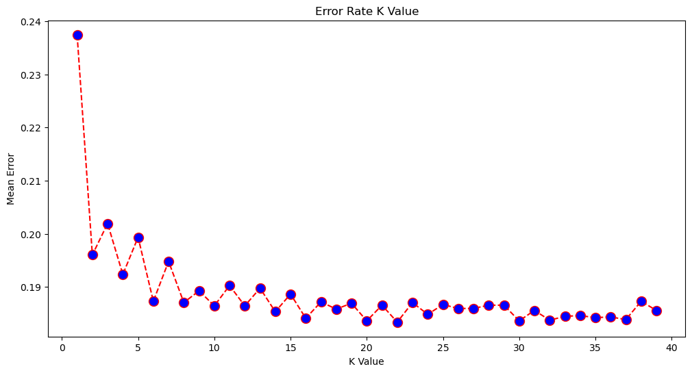

```python
## Calculating error for K values between 1 and 40
for i in range(1, 40):
    model = KNeighborsClassifier(n_neighbors=i)
    model.fit(X_train, y_train)
    pred_i = model.predict(X_test)
    error.append(np.mean(pred_i != y_test))

plt.figure(figsize=(12, 6))
plt.plot(range(1, 40), error, color='red', linestyle='dashed', marker='o',
         markerfacecolor='blue', markersize=10)
plt.title('Error Rate K Value')
plt.xlabel('K Value')
plt.ylabel('Mean Error')
```

Here we are creating the graph so that we can check the Value of K. From the graph we can clerly say the point 1 i.e. value of k=1 is having the most error while the value of K=22 is having the least error so if we use the value of K having less error we will get good model accuracy. As the Value of K is hard to find we can find and take on the basic of the graph plotted above.

### *Training the Model*

```python
## Fitting the data into model
from sklearn.neighbors import KNeighborsClassifier
model = KNeighborsClassifier(n_neighbors = 2, metric = 'minkowski', p = 2)
model.fit(X_train, y_train)
```

```
KNeighborsClassifier(n_neighbors=2)
```

#### Here we can change the value of K depending on our understanding and need.

```python
age = int(input("Enter New Employee's Age: "))
edu = int(input("Enter New Employee's Education: "))
cg = int(input("Enter New Employee's Captital Gain: "))
wh = int(input("Enter New Employee's Hour's Per week: "))
newEmp = [[age,edu,cg,wh]]
result = model.predict(sc.transform(newEmp))
print(result)

if result == 1:
  print("Employee might got Salary above 50K")
else:
  print("Customer might not got  Salary above 50K")
```

```
Enter New Employee's Age: 68
Enter New Employee's Education: 9
Enter New Employee's Captital Gain: 0
Enter New Employee's Hour's Per week: 40
[0]
Customer might not got  Salary above 50K
```

### *Prediction for all Test Data*

```python
y_pred = model.predict(X_test)
print(np.concatenate((y_pred.reshape(len(y_pred),1), y_test.reshape(len(y_test),1)),1))
```

```
[[0 0]
 [0 0]
 [0 0]
 ...
 [0 0]
 [0 0]
 [0 0]]
```

### *Evaluating Model - CONFUSION MATRIX*

```python
from sklearn.metrics import confusion_matrix, accuracy_score
cm = confusion_matrix(y_test, y_pred)

print("Confusion Matrix: ")
print(cm)

print("Accuracy of the Model: {0}%".format(accuracy_score(y_test, y_pred)*100))
```

```
Confusion Matrix:
[[5916  277]
 [1319  629]]
Accuracy of the Model: 80.39552880481513%
```

## Conclusion

- Here we are creating the graph so that we can check the Value of K. From the graph we can clerly say the point 1 i.e. value of k=1 is having the most error while the value of K=22 is having the least error so if we use the value of K having less error we will get good model accuracy. As the Value of K is hard to find we can find and take on the basic of the graph plotted above.

```
                     - - - - - - - - X X X X X X X X - - - - - - - -
```